```python
import numpy as np
import pandas as pd
import matplotlib.pyplot as plt

import tensorflow as tf
from keras.layers import Dense, Conv2D, Dropout, MaxPooling2D, GlobalAveragePooling2D, Flatten
from keras.models import Sequential
from keras.preprocessing.image import ImageDataGenerator
from keras.datasets import cifar10
from keras.utils import np_utils
from keras.constraints import maxnorm
from keras.optimizers import SGD
from keras.callbacks import LearningRateScheduler, ReduceLROnPlateau

from sklearn.preprocessing import OneHotEncoder

import os
import warnings
warnings.filterwarnings('ignore')

%matplotlib inline
```

# Loading Data

Below we are loading CIFAR10 dataset which has 50k train samples and 10k test samples.

```python
(X_train, Y_train), (X_test, Y_test) = cifar10.load_data()
X_train.shape, Y_train.shape, X_test.shape, Y_test.shape
```

```
Downloading data from https://www.cs.toronto.edu/~kriz/cifar-10-python.tar.gz
```

```
((50000, 32, 32, 3), (50000, 1), (10000, 32, 32, 3), (10000, 1))
```

## Plotting First Few Images

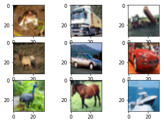

```python
for i in range(0, 9):
    plt.subplot(330 + 1 + i)
    plt.imshow(X_train[i])
plt.show()
```

## Rescaling Data

Below we are dividing data of each image by 255 so that all values in all images stays between 0-1.0. In short we are rescaling image data between 0-1.0 so that training runs faster and converges fast.

```python
X_train = X_train.astype('float32')
X_test = X_test.astype('float32')
X_train = X_train / 255.0
X_test = X_test / 255.0
```

## One Hot Encoding Of Targets

Below we are using `np_utils` module of `keras` to transform train/test targets to one hot encoded targets.

```python
Y_train = np_utils.to_categorical(Y_train)
Y_test = np_utils.to_categorical(Y_test)
num_classes = Y_test.shape[1]
```

## Function For Plotting Train/Validation Accuracy & Loss per Epoch.

Below function takes as input history object generated by trained keras model which keeps tracks of loss and accuracy for train/validation sets and then plots it.

```python
def plot_acc_loss(history):
    with plt.style.context(('seaborn', 'ggplot')):
        plt.figure(figsize=(15,6))
        plt.subplot(121)
        plt.plot(range(len(history.history['accuracy'])), history.history['accuracy'], label='Train Accuracy')
        #plt.scatter(range(len(history.history['accuracy'])), history.history['accuracy'])
        plt.plot(range(len(history.history['val_accuracy'])), history.history['val_accuracy'], label='Validation accuracy')
        #plt.scatter(range(len(history.history['val_accuracy'])), history.history['val_accuracy'])
        plt.xlabel('Epochs')
        plt.ylabel('Accuracy')
        plt.legend(loc='best')

        plt.subplot(122)
        plt.plot(range(len(history.history['loss'])), history.history['loss'], label='Train Loss')
        #plt.scatter(range(len(history.history['loss'])), history.history['loss'])
        plt.plot(range(len(history.history['val_loss'])), history.history['val_loss'], label='Validation Loss')
        #plt.scatter(range(len(history.history['val_loss'])), history.history['val_loss'])
        plt.xlabel('Epochs')
        plt.ylabel('Loss')
        plt.legend(loc='best')
```

# 1. Simple Convolutional Neural Network

Our first model is simple model with 2 convoluation layers.It has two convolutional layers followed by max pooling and a flattening out of the network to fully connected layers to make predictions.

1. Convolutional input layer, 32 feature maps with a size of 3×3, a rectifier activation function and a weight constraint of max norm set to 3.
2. Dropout set to 20%.
3. Convolutional layer, 32 feature maps with a size of 3×3, a rectifier activation function and a weight constraint of max norm set to 3.
4. Max Pool layer with size 2×2.
5. Flatten layer.
6. Fully connected layer with 512 units and a rectifier activation function.
7. Dropout set to 50%.
8. Fully connected output layer with 10 units and a softmax activation function.

```python
def conv_model_v1():
    model = Sequential()
    model.add(Conv2D(32, (3, 3), input_shape=(32, 32, 3), padding='same', activation='relu', kernel_constraint=maxnorm(3)))
    model.add(Dropout(0.2))
    model.add(Conv2D(32, (3, 3), activation='relu', padding='same', kernel_constraint=maxnorm(3)))
    model.add(MaxPooling2D(pool_size=(2, 2)))
    model.add(Flatten())
    model.add(Dense(512, activation='relu', kernel_constraint=maxnorm(3)))
    model.add(Dropout(0.5))
    model.add(Dense(num_classes, activation='softmax'))
    return model
```

## Compiling Model

Below we have initialized model with stochastic gradient descent and loss function of categorical crossentropy (logarithmic loss for multiclass problems). We have used accuracy is metrics of evaluation. SGD will be initialized with learning rate of 0.01.

```python
model = conv_model_v1()
# Compile model
epochs = 25
lrate = 0.01
decay = lrate/epochs
sgd = SGD(lr=lrate, momentum=0.9, decay=decay, nesterov=False)
model.compile(loss='categorical_crossentropy', optimizer=sgd, metrics=['accuracy'])
model.summary()
```

```
Model: "sequential_1"
_________________________________________________________________
Layer (type)                 Output Shape              Param #
=================================================================
conv2d_1 (Conv2D)            (None, 32, 32, 32)        896
_________________________________________________________________
dropout_1 (Dropout)          (None, 32, 32, 32)        0
_________________________________________________________________
conv2d_2 (Conv2D)            (None, 32, 32, 32)        9248
_________________________________________________________________
max_pooling2d_1 (MaxPooling2 (None, 16, 16, 32)        0
_________________________________________________________________
flatten_1 (Flatten)          (None, 8192)              0
_________________________________________________________________
dense_1 (Dense)              (None, 512)               4194816
_________________________________________________________________
dropout_2 (Dropout)          (None, 512)               0
_________________________________________________________________
dense_2 (Dense)              (None, 10)                5130
=================================================================
Total params: 4,210,090
Trainable params: 4,210,090
Non-trainable params: 0
_________________________________________________________________
```

## Fitting Model

Below we are fitting our simple model to train data and evaluating its performance on test data for each epoch. We'll be running training for 25 epochs in total. Each epoch makes one full turn through all data samples. We'll be printing accuracy on test data as well once training completes.

```python
%%time

history = model.fit(X_train, Y_train, validation_data=(X_test, Y_test), epochs=epochs, batch_size=32, verbose=2)
# Final evaluation of the model
scores = model.evaluate(X_test, Y_test, verbose=0)
print("Accuracy: %.2f%%" % (scores[1]*100))
```

```
Train on 50000 samples, validate on 10000 samples
 - 11s - loss: 1.7060 - accuracy: 0.3819 - val_loss: 1.5214 - val_accuracy: 0.4558
 - 9s - loss: 1.3792 - accuracy: 0.5039 - val_loss: 1.2364 - val_accuracy: 0.5550
 - 9s - loss: 1.2087 - accuracy: 0.5663 - val_loss: 1.1456 - val_accuracy: 0.5905
 - 9s - loss: 1.0903 - accuracy: 0.6136 - val_loss: 1.0661 - val_accuracy: 0.6219
 - 9s - loss: 0.9973 - accuracy: 0.6470 - val_loss: 1.0302 - val_accuracy: 0.6374
 - 9s - loss: 0.9147 - accuracy: 0.6762 - val_loss: 0.9909 - val_accuracy: 0.6511
 - 9s - loss: 0.8409 - accuracy: 0.7041 - val_loss: 0.9575 - val_accuracy: 0.6619
 - 9s - loss: 0.7808 - accuracy: 0.7230 - val_loss: 0.9425 - val_accuracy: 0.6704
 - 9s - loss: 0.7233 - accuracy: 0.7436 - val_loss: 0.9457 - val_accuracy: 0.6723
 - 9s - loss: 0.6683 - accuracy: 0.7650 - val_loss: 0.9509 - val_accuracy: 0.6744
 - 9s - loss: 0.6215 - accuracy: 0.7811 - val_loss: 0.9343 - val_accuracy: 0.6811
 - 9s - loss: 0.5829 - accuracy: 0.7938 - val_loss: 0.9298 - val_accuracy: 0.6855
 - 9s - loss: 0.5393 - accuracy: 0.8069 - val_loss: 0.9295 - val_accuracy: 0.6877
 - 9s - loss: 0.5046 - accuracy: 0.8218 - val_loss: 0.9606 - val_accuracy: 0.6869
 - 9s - loss: 0.4698 - accuracy: 0.8341 - val_loss: 0.9582 - val_accuracy: 0.6909
 - 9s - loss: 0.4431 - accuracy: 0.8446 - val_loss: 0.9548 - val_accuracy: 0.6973
 - 9s - loss: 0.4144 - accuracy: 0.8543 - val_loss: 0.9611 - val_accuracy: 0.6924
 - 9s - loss: 0.3940 - accuracy: 0.8602 - val_loss: 0.9797 - val_accuracy: 0.6977
 - 9s - loss: 0.3707 - accuracy: 0.8690 - val_loss: 0.9846 - val_accuracy: 0.6983
 - 9s - loss: 0.3492 - accuracy: 0.8769 - val_loss: 0.9826 - val_accuracy: 0.6960
 - 9s - loss: 0.3314 - accuracy: 0.8834 - val_loss: 0.9950 - val_accuracy: 0.6989
 - 9s - loss: 0.3165 - accuracy: 0.8888 - val_loss: 1.0169 - val_accuracy: 0.6991
 - 9s - loss: 0.3006 - accuracy: 0.8950 - val_loss: 1.0280 - val_accuracy: 0.6998
 - 9s - loss: 0.2894 - accuracy: 0.8984 - val_loss: 1.0309 - val_accuracy: 0.6988
 - 9s - loss: 0.2711 - accuracy: 0.9056 - val_loss: 1.0366 - val_accuracy: 0.7011
Accuracy: 70.11%
CPU times: user 4min 6s, sys: 55.5 s, total: 5min 2s
Wall time: 3min 44s
```

## Plotting Accuracy & Loss on Train/Validation Sets

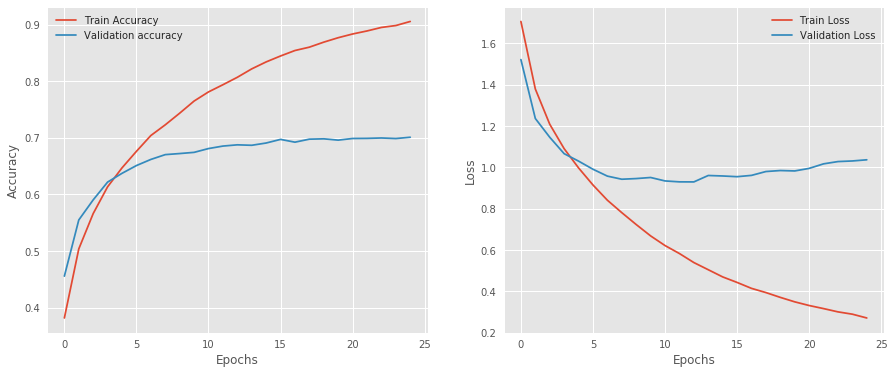

```python
plot_acc_loss(history)
```

# 2. Large Convolutional Neural Network

As our previous simple model did not perform quite well, we'll try to introduce little complicated covolutional model. We'll be introducing more convolutional layers and following patters of 4 layers(Conv layer, Dropout layer, Conv layer, MaxPooling layer) with different input units (32,64,128). We'll then flatten output of last conv layer and feed it into Dense layers further.

Please find below architecture layers:

1. Convolutional input layer, 32 feature maps with a size of 3×3 and a rectifier activation function.
2. Dropout layer at 20%.
3. Convolutional layer, 32 feature maps with a size of 3×3 and a rectifier activation function.
4. Max Pool layer with size 2×2.
5. Convolutional layer, 64 feature maps with a size of 3×3 and a rectifier activation function.
6. Dropout layer at 20%.
7. Convolutional layer, 64 feature maps with a size of 3×3 and a rectifier activation function.
8. Max Pool layer with size 2×2.
9. Convolutional layer, 128 feature maps with a size of 3×3 and a rectifier activation function.
10. Dropout layer at 20%.
11. Convolutional layer,128 feature maps with a size of 3×3 and a rectifier activation function.
12. Max Pool layer with size 2×2.
13. Flatten layer.
14. Dropout layer at 20%.
15. Fully connected layer with 1024 units and a rectifier activation function.
16. Dropout layer at 20%.
17. Fully connected layer with 512 units and a rectifier activation function.
18. Dropout layer at 20%.
19. Fully connected output layer with 10 units and a softmax activation function.

```python
def conv_model_v2():
    model = Sequential()
    model.add(Conv2D(32, (3, 3), input_shape=(32, 32, 3), activation='relu', padding='same'))
    model.add(Dropout(0.2))
    model.add(Conv2D(32, (3, 3), activation='relu', padding='same'))
    model.add(MaxPooling2D())
    model.add(Conv2D(64, (3, 3), activation='relu', padding='same'))
    model.add(Dropout(0.2))
    model.add(Conv2D(64, (3, 3), activation='relu', padding='same'))
    model.add(MaxPooling2D())
    model.add(Conv2D(128, (3, 3), activation='relu', padding='same'))
    model.add(Dropout(0.2))
    model.add(Conv2D(128, (3, 3), activation='relu', padding='same'))
    model.add(MaxPooling2D())
    model.add(Flatten())
    model.add(Dropout(0.2))
    model.add(Dense(1024, activation='relu', kernel_constraint=maxnorm(3)))
    model.add(Dropout(0.2))
    model.add(Dense(512, activation='relu', kernel_constraint=maxnorm(3)))
    model.add(Dropout(0.2))
    model.add(Dense(num_classes, activation='softmax'))
    return model
```

## Compiling Model

Below we have initialized model with stochastic gradient descent and loss function of categorical crossentropy (logarithmic loss for multiclass problems). We have used accuracy is metrics of evaluation. SGD will be initialized with learning rate of 0.01.

```python
model = conv_model_v2()
epochs = 25
lrate = 0.01
decay = lrate/epochs
sgd = SGD(lr=lrate, momentum=0.9, decay=decay, nesterov=False)
model.compile(loss='categorical_crossentropy', optimizer=sgd, metrics=['accuracy'])
model.summary()
```

```
Model: "sequential_2"
_________________________________________________________________
Layer (type)                 Output Shape              Param #
=================================================================
conv2d_3 (Conv2D)            (None, 32, 32, 32)        896
_________________________________________________________________
dropout_3 (Dropout)          (None, 32, 32, 32)        0
_________________________________________________________________
conv2d_4 (Conv2D)            (None, 32, 32, 32)        9248
_________________________________________________________________
max_pooling2d_2 (MaxPooling2 (None, 16, 16, 32)        0
_________________________________________________________________
conv2d_5 (Conv2D)            (None, 16, 16, 64)        18496
_________________________________________________________________
dropout_4 (Dropout)          (None, 16, 16, 64)        0
_________________________________________________________________
conv2d_6 (Conv2D)            (None, 16, 16, 64)        36928
_________________________________________________________________
max_pooling2d_3 (MaxPooling2 (None, 8, 8, 64)          0
_________________________________________________________________
conv2d_7 (Conv2D)            (None, 8, 8, 128)         73856
_________________________________________________________________
dropout_5 (Dropout)          (None, 8, 8, 128)         0
_________________________________________________________________
conv2d_8 (Conv2D)            (None, 8, 8, 128)         147584
_________________________________________________________________
max_pooling2d_4 (MaxPooling2 (None, 4, 4, 128)         0
_________________________________________________________________
flatten_2 (Flatten)          (None, 2048)              0
_________________________________________________________________
dropout_6 (Dropout)          (None, 2048)              0
_________________________________________________________________
dense_3 (Dense)              (None, 1024)              2098176
_________________________________________________________________
dropout_7 (Dropout)          (None, 1024)              0
_________________________________________________________________
dense_4 (Dense)              (None, 512)               524800
_________________________________________________________________
dropout_8 (Dropout)          (None, 512)               0
_________________________________________________________________
dense_5 (Dense)              (None, 10)                5130
=================================================================
Total params: 2,915,114
Trainable params: 2,915,114
Non-trainable params: 0
_________________________________________________________________
```

## Fitting Model

```python
%%time

history = model.fit(X_train, Y_train, validation_data=(X_test, Y_test), epochs=epochs, batch_size=64, verbose=2)
# Final evaluation of the model
scores = model.evaluate(X_test, Y_test, verbose=0)
print("Accuracy: %.2f%%" % (scores[1]*100))
```

```
Train on 50000 samples, validate on 10000 samples
 - 8s - loss: 1.9624 - accuracy: 0.2758 - val_loss: 1.6218 - val_accuracy: 0.4160
 - 7s - loss: 1.5250 - accuracy: 0.4454 - val_loss: 1.3434 - val_accuracy: 0.5138
 - 7s - loss: 1.3340 - accuracy: 0.5168 - val_loss: 1.2723 - val_accuracy: 0.5387
 - 7s - loss: 1.2063 - accuracy: 0.5653 - val_loss: 1.1141 - val_accuracy: 0.5976
 - 7s - loss: 1.0993 - accuracy: 0.6047 - val_loss: 1.0317 - val_accuracy: 0.6349
 - 7s - loss: 1.0054 - accuracy: 0.6400 - val_loss: 0.9625 - val_accuracy: 0.6548
 - 7s - loss: 0.9272 - accuracy: 0.6702 - val_loss: 0.8996 - val_accuracy: 0.6833
 - 7s - loss: 0.8637 - accuracy: 0.6941 - val_loss: 0.8600 - val_accuracy: 0.6989
 - 7s - loss: 0.8070 - accuracy: 0.7157 - val_loss: 0.8305 - val_accuracy: 0.7102
 - 7s - loss: 0.7575 - accuracy: 0.7318 - val_loss: 0.7797 - val_accuracy: 0.7276
 - 7s - loss: 0.7186 - accuracy: 0.7481 - val_loss: 0.7325 - val_accuracy: 0.7458
 - 8s - loss: 0.6798 - accuracy: 0.7596 - val_loss: 0.7063 - val_accuracy: 0.7545
 - 7s - loss: 0.6477 - accuracy: 0.7726 - val_loss: 0.7210 - val_accuracy: 0.7497
 - 7s - loss: 0.6261 - accuracy: 0.7795 - val_loss: 0.6840 - val_accuracy: 0.7634
 - 7s - loss: 0.5972 - accuracy: 0.7897 - val_loss: 0.6801 - val_accuracy: 0.7668
 - 7s - loss: 0.5737 - accuracy: 0.7982 - val_loss: 0.6845 - val_accuracy: 0.7663
 - 7s - loss: 0.5499 - accuracy: 0.8056 - val_loss: 0.6513 - val_accuracy: 0.7780
 - 7s - loss: 0.5317 - accuracy: 0.8119 - val_loss: 0.6556 - val_accuracy: 0.7791
 - 7s - loss: 0.5104 - accuracy: 0.8201 - val_loss: 0.6537 - val_accuracy: 0.7771
 - 7s - loss: 0.4920 - accuracy: 0.8250 - val_loss: 0.6555 - val_accuracy: 0.7769
 - 7s - loss: 0.4741 - accuracy: 0.8308 - val_loss: 0.6411 - val_accuracy: 0.7860
 - 7s - loss: 0.4626 - accuracy: 0.8360 - val_loss: 0.6288 - val_accuracy: 0.7894
 - 7s - loss: 0.4473 - accuracy: 0.8428 - val_loss: 0.6301 - val_accuracy: 0.7905
 - 7s - loss: 0.4303 - accuracy: 0.8475 - val_loss: 0.6263 - val_accuracy: 0.7908
 - 7s - loss: 0.4150 - accuracy: 0.8518 - val_loss: 0.6251 - val_accuracy: 0.7944
Accuracy: 79.44%
CPU times: user 2min 50s, sys: 43.5 s, total: 3min 33s
Wall time: 3min 6s
```

## Plotting Accuracy & Loss on Train/Validation Sets

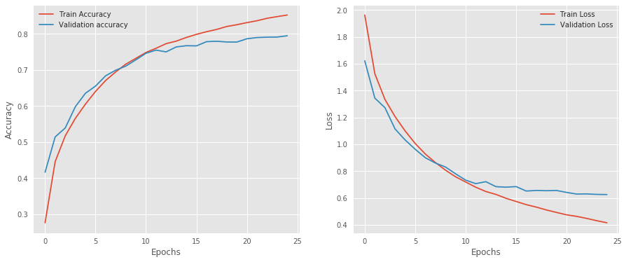

```python
plot_acc_loss(history)
```

# 3. Large Conv Net with More Epochs

Below we have used same convolutional layer previous step but we are trying model for more epochs. We are trying model for 200 epochs this time. Apart from increasing more epochs, we have also introduced strategy called `ReduceLROnPlateau` which will reduce learning rate by factor of 0.1 if validation loss is not improving constantly for 100 epochs. We'll be training model with same 64 batch size.

```python
%%time

model = conv_model_v2()
# Compile model
epochs = 200
lrate = 0.01
decay = lrate/epochs
sgd = SGD(lr=lrate, momentum=0.9, decay=decay, nesterov=False)
model.compile(loss='categorical_crossentropy', optimizer=sgd, metrics=['accuracy'])
reduce_lr = ReduceLROnPlateau(monitor='val_loss', factor=0.1, patience=100)
history = model.fit(X_train, Y_train, validation_data=(X_test, Y_test), epochs=epochs, batch_size=64, verbose=0, callbacks=[reduce_lr])
# Final evaluation of the model
scores = model.evaluate(X_test, Y_test, verbose=0)
print("Accuracy: %.2f%%" % (scores[1]*100))
```

```
Accuracy: 83.39%
CPU times: user 22min 24s, sys: 6min 3s, total: 28min 28s
Wall time: 24min 31s
```

## Plotting Accuracy & Loss on Train/Validation Sets

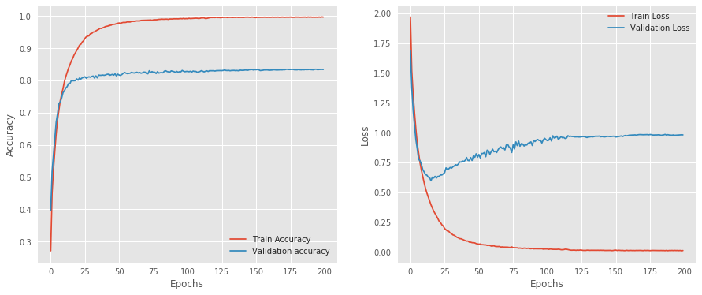

```python
plot_acc_loss(history)
```

# 4. Large Conv Net with Data Augmentation

Below we are trying same convolutional neural network as previous step but now we have introduced data augmentation into our data which will make slight modification to images and create extra images for training. This will give model more images to train which can help it improve accuracy further.

### Types of Data Augmentation:

**Image Rotation Angle:** Its degree by which image gets rotated. We have kept it to 30 degree as we don't won't to rotate much because real world images of some classes can't be upside down. Hence we have kept rotation to maximum of 30 degree.

**Horizontal Flip:** This will flip images horizontally.

**Zoom Range:** It range for zooming. We have kept it to 0.5 as we don't want to zoom much because our images are already small size (32 x 32 x 3).

**Height Shift Range:** It decides in what range height should be shifted. We have kept it to 0.15 which means we'll be shifting heights of images in 15% height of original image.

**Widht Shift Range:** It decides in what range height should be shifted. We have kept it to 0.15 which means we'll be shifting widths of images in 15% width of original image.

```python
train_img_gen = ImageDataGenerator(rotation_range=30, width_shift_range=.15, height_shift_range=.15, horizontal_flip=True, zoom_range=0.5)
train_data_gen = train_img_gen.flow(X_train, Y_train, batch_size=64)

val_img_gen = ImageDataGenerator()
val_data_gen = val_img_gen.flow(X_test, Y_test, batch_size=128, shuffle=False)
```

We'll be running model again for 200 epochs and batch size will be 64. We have also used strategy called `ReduceLROnPlateau` which will reduce learning rate by factor of 0.1 if validation loss is not improving constantly for 100 epochs.

```python
%%time

model = conv_model_v2()
# Compile model
epochs = 200
lrate = 0.01
decay = lrate/epochs
sgd = SGD(lr=lrate, momentum=0.9, decay=decay, nesterov=False)
model.compile(loss='categorical_crossentropy', optimizer=sgd, metrics=['accuracy'])
reduce_lr = ReduceLROnPlateau(monitor='val_loss', factor=0.1, patience=100)
history = model.fit_generator(train_data_gen, validation_data=val_data_gen, epochs=epochs, verbose=0, callbacks=[reduce_lr])
# Final evaluation of the model
scores = model.evaluate(X_test, Y_test, verbose=0)
print("Accuracy: %.2f%%" % (scores[1]*100))
```

```
Accuracy: 86.32%
CPU times: user 1h 42min 39s, sys: 4min 29s, total: 1h 47min 8s
Wall time: 1h 21min 10s
```

## Plotting Accuracy & Loss on Train/Validation Sets

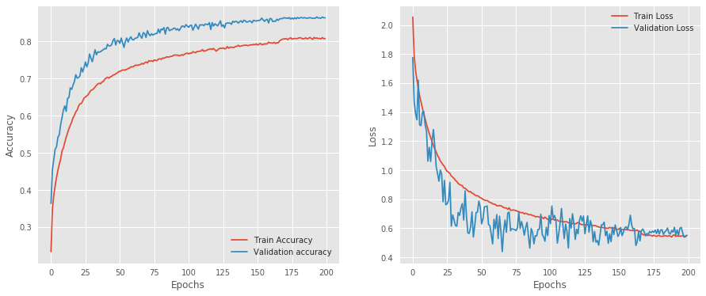

```python
plot_acc_loss(history)
```

# 5. Large ConvNet with Adam Optimizer

Below we have tried same convolutional model as our previous 3 steps but this time we have used Adam optimizer instead of SGD. Adam is adaptive optimizer which means that during training it adjusts its learning rate based on loss itself and we don't need to explicitly decrease it.

```python
%%time

model = conv_model_v2()
# Compile model
epochs = 200
model.compile(loss='categorical_crossentropy', optimizer='adam', metrics=['accuracy'])
history = model.fit(X_train, Y_train, validation_data=(X_test, Y_test), epochs=epochs, batch_size=64, verbose=0)
# Final evaluation of the model
scores = model.evaluate(X_test, Y_test, verbose=0)
print("Accuracy: %.2f%%" % (scores[1]*100))
```

```
Accuracy: 81.77%
CPU times: user 27min 16s, sys: 5min 19s, total: 32min 36s
Wall time: 28min 23s
```

## Plotting Accuracy & Loss on Train/Validation Sets

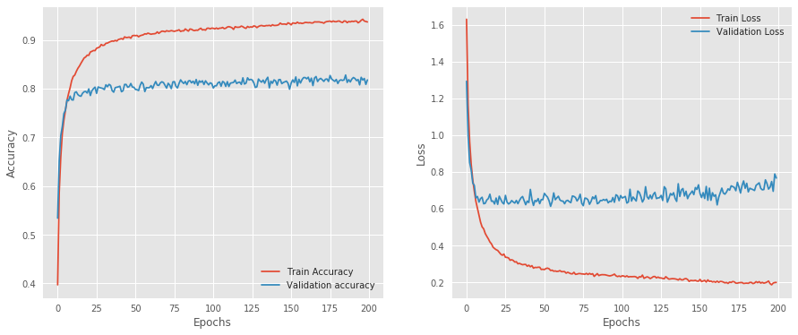

```python
plot_acc_loss(history)
```

# 6. Large Convolutional Neural Net v2

Below we have introduced another version of convolutional neural network.. We'll be introducing few more convolutional layers and following patters of 4 layers(Conv layer, Dropout layer, Conv layer, MaxPooling layer) with different input units (32,64,128, 256). We'll then flatten output of last conv layer and feed it into Dense layers further.

Please find below architecture layers:

1. Convolutional input layer, 32 feature maps with a size of 3×3 and a rectifier activation function.
2. Dropout layer at 20%.
3. Convolutional layer, 32 feature maps with a size of 3×3 and a rectifier activation function.
4. Max Pool layer with size 2×2.
5. Convolutional layer, 64 feature maps with a size of 3×3 and a rectifier activation function.
6. Dropout layer at 20%.
7. Convolutional layer, 64 feature maps with a size of 3×3 and a rectifier activation function.
8. Max Pool layer with size 2×2.
9. Convolutional layer, 128 feature maps with a size of 3×3 and a rectifier activation function.
10. Dropout layer at 20%.
11. Convolutional layer,128 feature maps with a size of 3×3 and a rectifier activation function.
12. Max Pool layer with size 2×2.
13. Convolutional layer, 256 feature maps with a size of 3×3 and a rectifier activation function.
14. Dropout layer at 20%.
15. Convolutional layer,256 feature maps with a size of 3×3 and a rectifier activation function.
16. Max Pool layer with size 2×2.
17. Flatten layer.
18. Dropout layer at 20%.
19. Fully connected layer with 1024 units and a rectifier activation function.
20. Dropout layer at 20%.
21. Fully connected layer with 512 units and a rectifier activation function.
22. Dropout layer at 20%.
23. Fully connected output layer with 10 units and a softmax activation function.

```python
def conv_model_v3():
    model = Sequential()
    model.add(Conv2D(32, (3, 3), input_shape=(32, 32, 3), activation='relu', padding='same'))
    model.add(Dropout(0.2))
    model.add(Conv2D(32, (3, 3), activation='relu', padding='same'))
    model.add(MaxPooling2D())
    model.add(Conv2D(64, (3, 3), activation='relu', padding='same'))
    model.add(Dropout(0.2))
    model.add(Conv2D(64, (3, 3), activation='relu', padding='same'))
    model.add(MaxPooling2D())
    model.add(Conv2D(128, (3, 3), activation='relu', padding='same'))
    model.add(Dropout(0.2))
    model.add(Conv2D(128, (3, 3), activation='relu', padding='same'))
    model.add(MaxPooling2D())
    model.add(Conv2D(256, (3, 3), activation='relu', padding='same'))
    model.add(Dropout(0.2))
    model.add(Conv2D(256, (3, 3), activation='relu', padding='same'))
    model.add(MaxPooling2D())
    model.add(Flatten())
    model.add(Dropout(0.2))
    model.add(Dense(1024, activation='relu', kernel_constraint=maxnorm(3)))
    model.add(Dropout(0.2))
    model.add(Dense(512, activation='relu', kernel_constraint=maxnorm(3)))
    model.add(Dropout(0.2))
    model.add(Dense(num_classes, activation='softmax'))
    return model

model = conv_model_v3()
epochs = 200
lrate = 0.01
decay = lrate/epochs
sgd = SGD(lr=lrate, momentum=0.9, decay=decay, nesterov=False)
model.compile(loss='categorical_crossentropy', optimizer=sgd, metrics=['accuracy'])
model.summary()
```

```
Model: "sequential_6"
_________________________________________________________________
Layer (type)                 Output Shape              Param #
=================================================================
conv2d_27 (Conv2D)           (None, 32, 32, 32)        896
_________________________________________________________________
dropout_27 (Dropout)         (None, 32, 32, 32)        0
_________________________________________________________________
conv2d_28 (Conv2D)           (None, 32, 32, 32)        9248
_________________________________________________________________
max_pooling2d_14 (MaxPooling (None, 16, 16, 32)        0
_________________________________________________________________
conv2d_29 (Conv2D)           (None, 16, 16, 64)        18496
_________________________________________________________________
dropout_28 (Dropout)         (None, 16, 16, 64)        0
_________________________________________________________________
conv2d_30 (Conv2D)           (None, 16, 16, 64)        36928
_________________________________________________________________
max_pooling2d_15 (MaxPooling (None, 8, 8, 64)          0
_________________________________________________________________
conv2d_31 (Conv2D)           (None, 8, 8, 128)         73856
_________________________________________________________________
dropout_29 (Dropout)         (None, 8, 8, 128)         0
_________________________________________________________________
conv2d_32 (Conv2D)           (None, 8, 8, 128)         147584
_________________________________________________________________
max_pooling2d_16 (MaxPooling (None, 4, 4, 128)         0
_________________________________________________________________
conv2d_33 (Conv2D)           (None, 4, 4, 256)         295168
_________________________________________________________________
dropout_30 (Dropout)         (None, 4, 4, 256)         0
_________________________________________________________________
conv2d_34 (Conv2D)           (None, 4, 4, 256)         590080
_________________________________________________________________
max_pooling2d_17 (MaxPooling (None, 2, 2, 256)         0
_________________________________________________________________
flatten_6 (Flatten)          (None, 1024)              0
_________________________________________________________________
dropout_31 (Dropout)         (None, 1024)              0
_________________________________________________________________
dense_15 (Dense)             (None, 1024)              1049600
_________________________________________________________________
dropout_32 (Dropout)         (None, 1024)              0
_________________________________________________________________
dense_16 (Dense)             (None, 512)               524800
_________________________________________________________________
dropout_33 (Dropout)         (None, 512)               0
_________________________________________________________________
dense_17 (Dense)             (None, 10)                5130
=================================================================
Total params: 2,751,786
Trainable params: 2,751,786
Non-trainable params: 0
_________________________________________________________________
```

## Fitting Model

Below we are fitting our convolutional model v2 to train data and evaluating its performance on test data for each epoch. We'll be running training for 200 epochs in total. Each epoch makes one full turn through all data samples. We'll be printing accuracy on test data as well once training completes.We are using batch size of 64.

```python
%%time

reduce_lr = ReduceLROnPlateau(monitor='val_loss', factor=0.1, patience=100)
history = model.fit(X_train, Y_train, validation_data=(X_test, Y_test), epochs=epochs, batch_size=64, verbose=0, callbacks=[reduce_lr])
# Final evaluation of the model
scores = model.evaluate(X_test, Y_test, verbose=0)
print("Accuracy: %.2f%%" % (scores[1]*100))
```

```
Accuracy: 82.82%
CPU times: user 24min 27s, sys: 6min 49s, total: 31min 16s
Wall time: 27min 52s
```

## Plotting Accuracy & Loss on Train/Validation Sets

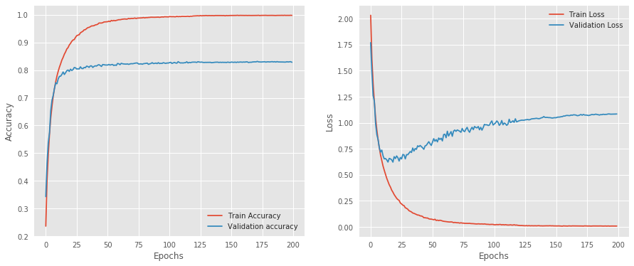

```python
plot_acc_loss(history)
```

# 7. Large Conv net v2 with Adam Optimizer

Below we are trying our previous large convolutional model v2 with same architecture but this time with `Adam` optimizer.Adam is adaptive optimizer which means that during training it adjusts its learning rate based on loss itself and we don't need to explicitly decrease it.

```python
%%time

model = conv_model_v3()
epochs = 200
model.compile(loss='categorical_crossentropy', optimizer='adam', metrics=['accuracy'])
history = model.fit(X_train, Y_train, validation_data=(X_test, Y_test), epochs=epochs, batch_size=64, verbose=0)
# Final evaluation of the model
scores = model.evaluate(X_test, Y_test, verbose=0)
print("Accuracy: %.2f%%" % (scores[1]*100))
```

```
Accuracy: 78.26%
CPU times: user 30min 34s, sys: 5min 35s, total: 36min 9s
Wall time: 32min 11s
```

## Plotting Accuracy & Loss on Train/Validation Sets

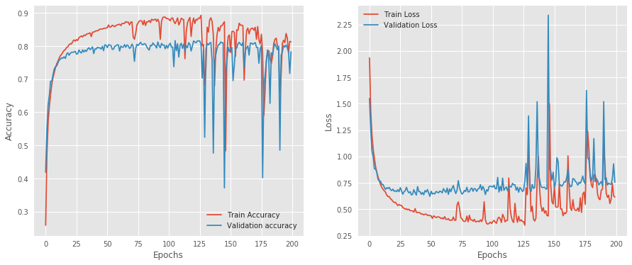

```python
plot_acc_loss(history)
```

# 9. Large Conv Net v2 with Data Augmentation

Below we are tring our same large convolutional model v2 with data augmentation.

### Types of Data Augmentation:

**Image Rotation Angle:** Its degree by which image gets rotated. We have kept it to 30 degree as we don't won't to rotate much because real world images of some classes can't be upside down. Hence we have kept rotation to maximum of 30 degree.

**Horizontal Flip:** This will flip images horizontally.

**Zoom Range:** It range for zooming. We have kept it to 0.5 as we don't want to zoom much because our images are already small size (32 x 32 x 3).

**Height Shift Range:** It decides in what range height should be shifted. We have kept it to 0.15 which means we'll be shifting heights of images in 15% height of original image.

**Widht Shift Range:** It decides in what range height should be shifted. We have kept it to 0.15 which means we'll be shifting widths of images in 15% width of original image.

```python
train_img_gen = ImageDataGenerator(rotation_range=30, width_shift_range=.15, height_shift_range=.15, horizontal_flip=True, zoom_range=0.5)
train_data_gen = train_img_gen.flow(X_train, Y_train, batch_size=64)

val_img_gen = ImageDataGenerator()
val_data_gen = val_img_gen.flow(X_test, Y_test, batch_size=128, shuffle=False)
```

## Fitting Model

Below we are fitting our convolutional model v2 to train data and evaluating its performance on test data for each epoch. We'll be running training for 200 epochs in total. Each epoch makes one full turn through all data samples. We'll be printing accuracy on test data as well once training completes.We are using batch size of 64.

```python
%%time

model = conv_model_v3()
# Compile model
epochs = 200
lrate = 0.01
decay = lrate/epochs
sgd = SGD(lr=lrate, momentum=0.9, decay=decay, nesterov=False)
model.compile(loss='categorical_crossentropy', optimizer=sgd, metrics=['accuracy'])
reduce_lr = ReduceLROnPlateau(monitor='val_loss', factor=0.1, patience=100)
history = model.fit_generator(train_data_gen, validation_data=val_data_gen, epochs=epochs, verbose=0, callbacks=[reduce_lr])
# Final evaluation of the model
scores = model.evaluate(X_test, Y_test, verbose=0)
print("Accuracy: %.2f%%" % (scores[1]*100))
```

```
Accuracy: 86.98%
CPU times: user 1h 46min 5s, sys: 4min 36s, total: 1h 50min 41s
Wall time: 1h 22min 6s
```

## Plotting Accuracy & Loss on Train/Validation Sets

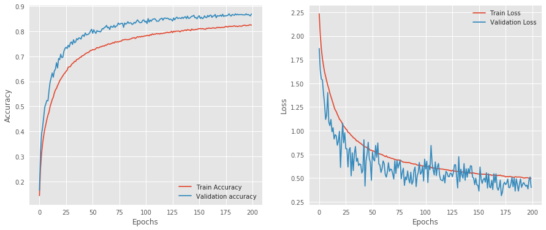

```python
plot_acc_loss(history)
```